# NEL CCG Templates

R Templates

## Introduction

When using R, libraries should be loaded at the top of the page so it is clear to the reader which packages are being used in the analysis. Common libraries include readxl (allows excel files to be imported to a vector) and tidyverse (contains a variety of data wrangling functions). More unique packages such as performanceanalytics or psych are useful for producing more visually accurate graphs or for a more customised visual. The dlookr and xray packages below are used for data quality purposes and can be used with the example dataset used here.

Note: Using multiple packages can result in masking errors. This is when two packages offer the same function. For example, running the code below will throw the mask error because dplyr and tidyverse can both summarise. Therefore, if you have no option but to run both packages, it is important to specify the package being called. For example, dplyr::summarise, rather than simply summarise. All packages on CRAN should have an associated guide which can be called from the helper window in R.

Below are some useful links:

**Getting Started in R**

Beginner Guide to R/Rstudio -> https://ourcodingclub.github.io/tutorials/intro-to-r/

Alternative Guide to R/RStudio -> https://www.dataquest.io/blog/tutorial-getting-started-with-r-and-rstudio/

Cheat Sheets -> https://www.rstudio.com/resources/cheatsheets/

CRAN -> https://cran.r-project.org/

Top 10 R Errors -> https://www.r-bloggers.com/2021/04/the-top-10-r-errors-the-7th-one-will-surprise-you/

6 Common Errors in R -> https://ismayc.github.io/rbasics-book/6-errors.html

**Coding Basics**

Dplyr Grammar -> https://dplyr.tidyverse.org/

Tidyverse Conference -> https://www.rstudio.com/resources/rstudioconf-2018/teach-the-tidyverse-to-beginners/

**Graph Basics**

Top 50 ggplot2 visualizations -> http://r-statistics.co/Top50-Ggplot2-Visualizations-MasterList-R-Code.html

R Gallery -> https://r-graph-gallery.com/ggplot2-package.html

## Libraries

```r
library(readxl)
library(tidyverse)
library(lubridate)
library(PerformanceAnalytics)
library(dlookr)
library(xray)
library(dplyr)
library(psych)
library(extrafont)
```

# Simple Visualisations

## Line Chart with Facet_Wrap

This graph uses the iris data set to represent the length and width of different flower species.  
The *facet_wrap* here makes the output split the results by species, as seen on the label.  
Things to consider: Number of groups, size of plot, dispersion of data.

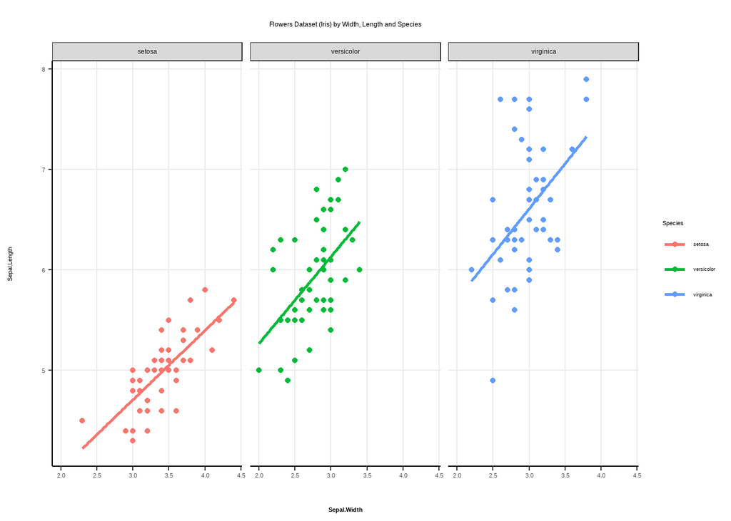

```r
flowers <- iris

ggplot(flowers, aes(x = Sepal.Width, y = Sepal.Length, fill = Species, color = Species)) +
  geom_point() +
  facet_wrap(~ Species) +
  ggtitle("Flowers Dataset (Iris) by Width, Length and Species") +
  geom_smooth(method = "lm", se = F) +
  theme_bw() +
  theme(axis.line.x = element_line(color = "Black"),
        axis.line.y = element_line(color = "Black"),
        panel.border = element_blank(),
        legend.position = "right",
        legend.title = element_text(size = 8),
        legend.text = element_text(size = 7),
        axis.text = element_text(size = 8),
        axis.title.x = element_text(size = 8, margin = margin(20,0,0,0), face = "bold"),
        axis.title.y = element_text(size = 8, margin = margin (0,20,0,0)),
        panel.grid.minor = element_blank(),
        plot.title = element_text(color = "black", size = 9, hjust = 0.5, margin = margin(10,0,10,00)))
```

## Grouped Freqpoly Graph

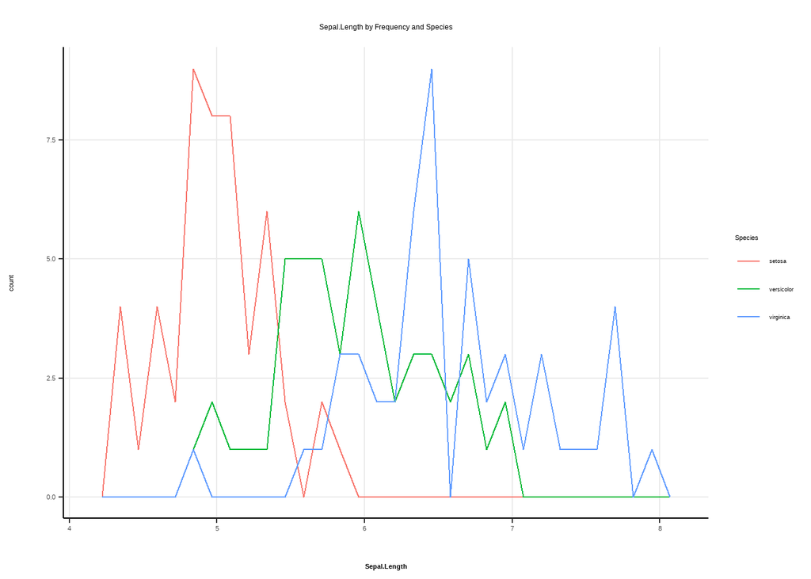

```r
ggplot(flowers, aes(x = Sepal.Length, fill = Species, color = Species)) +
  geom_freqpoly() +
  #facet_wrap(~ Method) +
  ggtitle("Sepal.Length by Frequency and Species") +
  theme_bw() +
  theme(axis.line.x = element_line(color = "Black"),
        axis.line.y = element_line(color = "Black"),
        panel.border = element_blank(),
        legend.position = "right",
        legend.title = element_text(size = 8),
        legend.text = element_text(size = 7),
        axis.text = element_text(size = 8),
        axis.title.x = element_text(size = 8, margin = margin(20,0,0,0), face = "bold"),
        axis.title.y = element_text(size = 8, margin = margin (0,20,0,0)),
        panel.grid.minor = element_blank(),
        plot.title = element_text(color = "black", size = 9, hjust = 0.5, margin = margin(10,0,10,00)))
```

## Grouped density plot

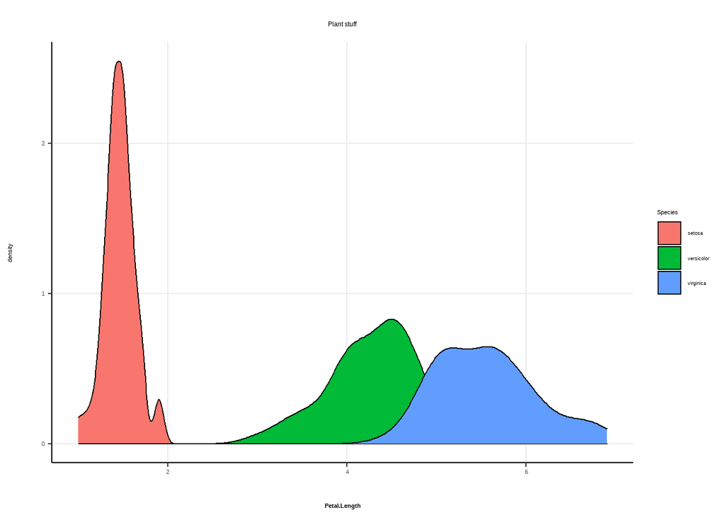

```r
ggplot(iris, aes(x = Petal.Length, fill = Species)) +
  geom_density(aplha = 0.3) +
  ggtitle("Plant stuff") +
  theme_bw() +
  theme(axis.line.x = element_line(color = "Black"),
        axis.line.y = element_line(color = "Black"),
        panel.border = element_blank(),
        legend.position = "right",
        legend.title = element_text(size = 8),
        legend.text = element_text(size = 7),
        axis.text = element_text(size = 8),
        axis.title.x = element_text(size = 8, margin = margin(20,0,0,0), face = "bold"),
        axis.title.y = element_text(size = 8, margin = margin (0,20,0,0)),
        panel.grid.minor = element_blank(),
        plot.title = element_text(color = "black", size = 9, hjust = 0.5, margin = margin(10,0,10,00)))
```

## Flipped violin density plot

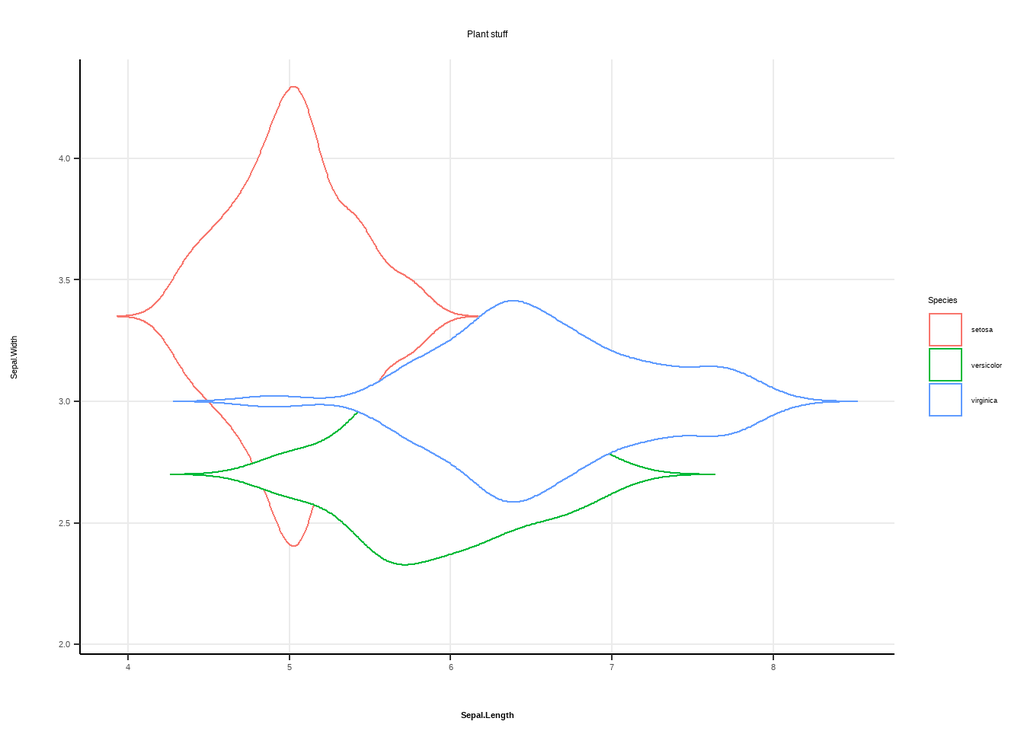

```r
ggplot(flowers, aes(x = Sepal.Width, y = Sepal.Length, color = Species)) +
  geom_violin(trim = FALSE) +
  ggtitle("Plant stuff") +
  theme_bw() +
  theme(axis.line.x = element_line(color = "Black"),
        axis.line.y = element_line(color = "Black"),
        panel.border = element_blank(),
        legend.position = "right",
        legend.title = element_text(size = 8),
        legend.text = element_text(size = 7),
        axis.text = element_text(size = 8),
        axis.title.x = element_text(size = 8, margin = margin(20,0,0,0), face = "bold"),
        axis.title.y = element_text(size = 8, margin = margin (0,20,0,0)),
        panel.grid.minor = element_blank(),
        plot.title = element_text(color = "black", size = 9, hjust = 0.5, margin = margin(10,0,10,00))) +
  coord_flip()
```

## Histogram grouped

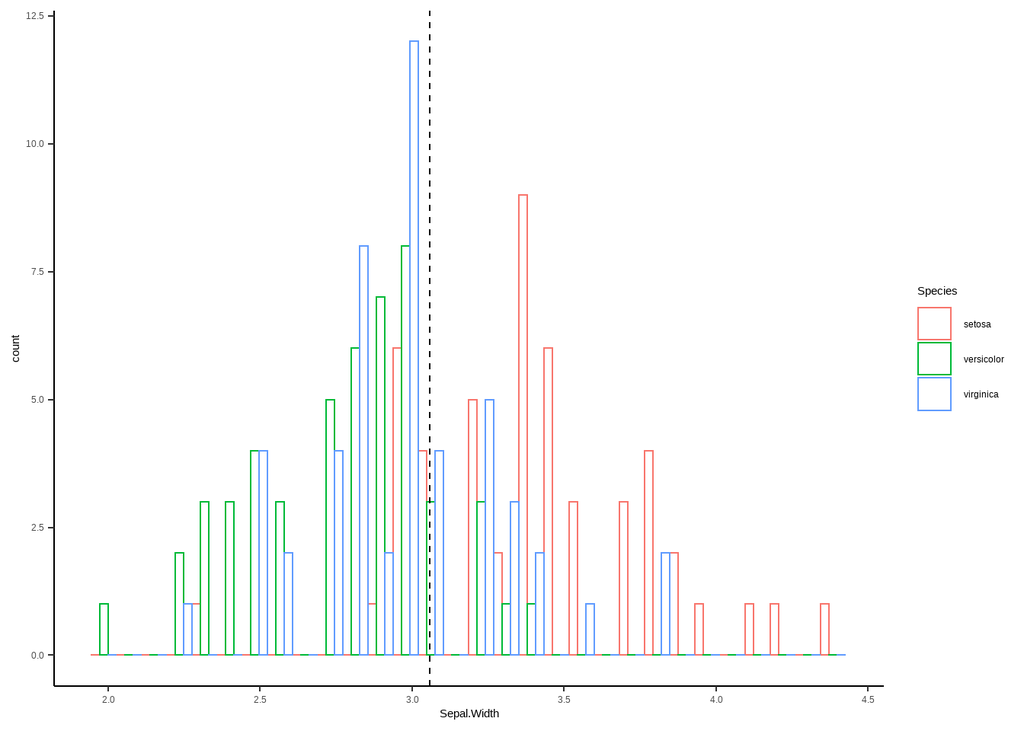

```r
ggplot(iris, aes(x=Sepal.Width, color=Species)) +
  geom_histogram(fill="white", position="dodge")+
  theme(legend.position="top")+
  geom_vline(data=iris, aes(xintercept=mean(Sepal.Width), group = Species),
             linetype="dashed")+
  theme(legend.position="top") +
  theme_classic()
```

## Boxplot

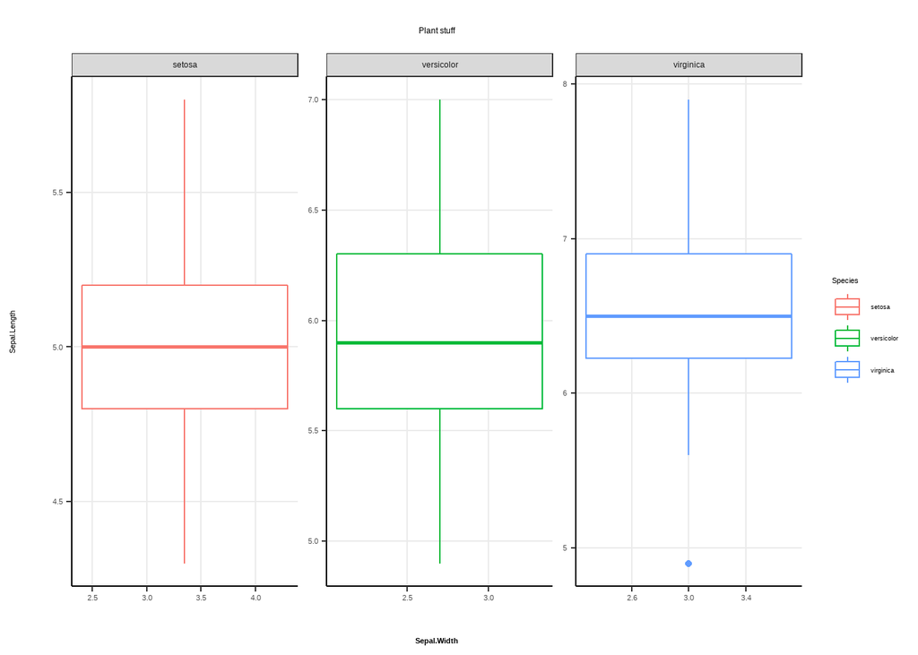

```r
ggplot(flowers, aes(x = Sepal.Width, y = Sepal.Length, color = Species)) +
  geom_boxplot() +
  facet_wrap(~ Species, scales = "free") +
  ggtitle("Plant stuff") +
  theme_bw() +
  theme(axis.line.x = element_line(color = "Black"),
        axis.line.y = element_line(color = "Black"),
        panel.border = element_blank(),
        legend.position = "right",
        legend.title = element_text(size = 8),
        legend.text = element_text(size = 7),
        axis.text = element_text(size = 8),
        axis.title.x = element_text(size = 8, margin = margin(20,0,0,0), face = "bold"),
        axis.title.y = element_text(size = 8, margin = margin (0,20,0,0)),
        panel.grid.minor = element_blank(),
        plot.title = element_text(color = "black", size = 9, hjust = 0.5, margin = margin(10,0,10,00)))
```